# Regression Models Course Project of Motor Trend

Relationship between MPG and transmissions

JackHo

4 June 2017

#### 1. Data Preparation

Load essential packages.

```r
library(MASS);library(car);library(dplyr);library(ggplot2);library(knitr);library(broom)
```

Load data into environment.

```r
mt_cars <- datasets::mtcars
```

Since the target of this analyse lies on finding the relationship between a set of variables and miles per gallon (MPG) and the company is particularly interested in **“Is an automatic or manual transmissions better for MPG”** and **“Quantify the MPG difference between automatic and manual transmissionss”**, I will firstly refine the data with only keeping the `am` and `mpg` variables.

```r
mt_cars <- mt_cars %>% dplyr:: select(mpg,am)
```

#### 2. Data Sleuthing

The variable `am` is a binary variable, which represents the status of the transmissions (0 = automatic, 1 = manual) of every cars. While the `mpg` variable means the miles/galon (US).

As shown below, there are 13 cars have the manual transmissions and 19 cars have the automatic one.

```r
tapply(X = mt_cars$mpg,INDEX = mt_cars$am,length)
```

```
##  0  1
## 19 13
```

Now I could quantify the MPG difference between automatic and manual transmissionss that:

```r
tapply(X = mt_cars$mpg,INDEX = mt_cars$am,summary)
```

```
## $`0`
##    Min. 1st Qu.  Median    Mean 3rd Qu.    Max.
##   10.40   14.95   17.30   17.15   19.20   24.40
##
## $`1`
##    Min. 1st Qu.  Median    Mean 3rd Qu.    Max.
##   15.00   21.00   22.80   24.39   30.40   33.90
```

#### 3. Build the Linear Model

Firstly, let’s build a one-variable linear model, where mpg is a the outcome and the am is independent variable.

```r
mt_cars$am <- as.factor(mt_cars$am)
model <- lm(data = mt_cars, mpg~ am)
```

From the `model`, we could basically get the formul:

$mpg = 7.244939 \times am + 17.147368$

which means the manual cars cost more *7.244949*/galon (US) in average of mpg than automatic cars do.

```r
summary(model) %>% tidy()
```

```
##          term  estimate std.error statistic      p.value
## 1 (Intercept) 17.147368  1.124603 15.247492 1.133983e-15
## 2         am1  7.244939  1.764422  4.106127 2.850207e-04
```

```r
summary(model) %>% glance()
```

```
##   r.squared adj.r.squared    sigma statistic      p.value df
## 1 0.3597989     0.3384589 4.902029  16.86028 0.0002850207  2
```

The `p.value` is *0.0002850207* shows that the model is credible. However, from the value of the `r.squared` and its adjusted value (*0.3597989* and *0.3384589*), the model can only explain about 35% of dependent data. Thus, I decide to add more variables in order to improve the model.

#### 4. Improve the model and Diagnose It

Next, after adding more predictors into the model, the results show that the overall model is significant (3.793152e-07) and the r-squared value is high (87%), but many independent variables are non-significant and I guess this might be because of the multicollinearity problem.

```r
mt_cars <- datasets::mtcars
mt_cars$am <- as.factor(mt_cars$am)
model <- lm(data = mt_cars,mpg~.)
summary(model)$coef
```

```
##                Estimate  Std. Error    t value   Pr(>|t|)
## (Intercept) 12.30337416 18.71788443  0.6573058 0.51812440
## cyl         -0.11144048  1.04502336 -0.1066392 0.91608738
## disp         0.01333524  0.01785750  0.7467585 0.46348865
## hp          -0.02148212  0.02176858 -0.9868407 0.33495531
## drat         0.78711097  1.63537307  0.4813036 0.63527790
## wt          -3.71530393  1.89441430 -1.9611887 0.06325215
## qsec         0.82104075  0.73084480  1.1234133 0.27394127
## vs           0.31776281  2.10450861  0.1509915 0.88142347
## am1          2.52022689  2.05665055  1.2254035 0.23398971
## gear         0.65541302  1.49325996  0.4389142 0.66520643
## carb        -0.19941925  0.82875250 -0.2406258 0.81217871
```

```r
summary(model) %>% glance()
```

```
##   r.squared adj.r.squared    sigma statistic      p.value df
## 1 0.8690158     0.8066423 2.650197  13.93246 3.793152e-07 11
```

Then, to figure out whether I add in some real-unnecessary variables, I decide to apply the `stepAIC()` function to help me filter the useful variables.

```r
model1 <- stepAIC(object = model, direction = "both")
summary(model1)$coef
summary(model1) %>% glance()
```

[output not shown]

Now, based on the new model, I get a new formula:

$mpg = -3.916504 \times wt + 1.225886 \times qsec + 2.935837 \times am + 9.617781$

which means with the `wt` and `qsec` remained, manual cars cost more *2.935837*/galon (US) in average of mpg than automatic cars do. Meanwhile, the new model shows the coefficients of variables are significant, explains about 85% original data and it is a significant model (`p.value` = *1.210446e^-11*)

Although the statics show that the new model is quite good, there are some essential diagnostics should be processed in order to make sure the model is really creidble.

- Outliers: (Refer to the Appendix 2)

```r
outlierTest(model1)
```

```
##
## No Studentized residuals with Bonferonni p < 0.05
## Largest |rstudent|:
##                   rstudent unadjusted p-value Bonferonni p
## Chrysler Imperial 2.323119           0.027949      0.89437
```

```r
hatvalues(model1)[order(hatvalues(model1),decreasing = T)] %>% head(5)
```

```
##            Merc 230 Lincoln Continental   Chrysler Imperial
##           0.2970422           0.2642151           0.2296338
##  Cadillac Fleetwood       Maserati Bora
##           0.2270069           0.1909815
```

```r
# cutoff <- 4/((nrow(mtcars)-length(model1$coefficients)-2))
# plot(model1, which=c(4,5), cook.levels=cutoff)
```

```r
new_model <- lm(data= mt_cars[-which(row.names(mt_cars) == "Chrysler Imperial"),], mpg~.) %>% stepAIC()
```

In model without “Chrysler Imperial”, the model is more significant and can explain more data. However, the variable am is not significant anymore. Let’s see whether it should be excluded.

```r
anova(update(new_model,.~.-am),new_model)
```

```
## Analysis of Variance Table
##
## Model 1: mpg ~ wt + qsec
## Model 2: mpg ~ wt + qsec + am
##   Res.Df    RSS Df Sum of Sq      F Pr(>F)
## 1     28 154.94
## 2     27 141.09  1    13.858 2.6521  0.115
```

```r
summary(update(new_model,.~.-am))$r.squared - summary(new_model)$r.squared
```

```
## [1] -0.01264364
```

Although the `anova()` tell us that even the `am` is excluded, the model will not be affected a lot, to keep a higher r.squared value, I decide not to delete it.

To improve the model, I try to interact the am, wt and qsec.

```r
model_int <- update(new_model,.~.+ am:wt + am:qsec) %>% stepAIC()
```

```r
anova(new_model,model_int)
```

```
## Analysis of Variance Table
##
## Model 1: mpg ~ wt + qsec + am
## Model 2: mpg ~ wt + qsec + am + wt:am
##   Res.Df    RSS Df Sum of Sq      F   Pr(>F)
## 1     27 141.09
## 2     26 105.04  1    36.046 8.9224 0.006073 **
## ---
## Signif. codes:  0 '***' 0.001 '**' 0.01 '*' 0.05 '.' 0.1 ' ' 1
```

```r
model_int %>% summary() %>% glance()
```

```
##   r.squared adj.r.squared    sigma statistic      p.value df
## 1 0.9041659     0.8894222 2.009966  61.32557 7.335181e-13  5
```

Finally, the model could explain *90.4%* data and is overall significant (p.value = *7.335181e-13*).

- Multicollinearity:

Owning to the help of `stepAIC()`, I exclude several of vairables at the beginning, now let’s check whether the `model_int` got that issue:

```r
sqrt(vif(model_int))>2
```

```
##    wt  qsec    am wt:am
## FALSE FALSE  TRUE  TRUE
```

```r
tmp <- mtcars %>% dplyr::select(wt,am,qsec)
tmp$wt_am <- tmp$wt*tmp$am
kappa(cor(tmp))
```

```
## [1] 110.0319
```

- Heteroskedasticity: (Refer to the Appendix 2)

**The dots in the graph “Check the Heteroskedasticity” have no particular pattern, which means this model does not have non-linear relationships and no heteroskedasticity**.

- Normality: (Refer to the Appendix 2)

#### 5. Summary

The `mpg` can be explained by `am`, `wt` and `qesc`, and their relationship can be denoted as below:

$mpg = 12.0638 \times am - 3.5641 \times wt + 0.9835 \times qesc - 3.5799 \times am \times wt + 12.4791$

#### Appendix

- Appendix 1

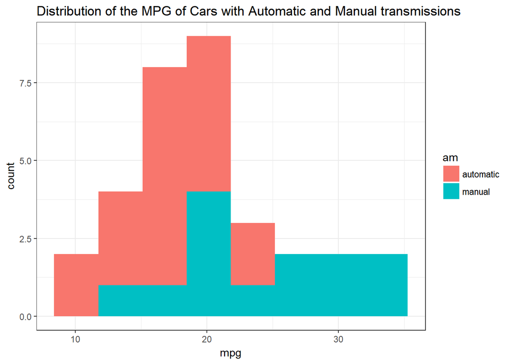

```r
ggplot(data = mt_cars %>% mutate(am =factor(mt_cars$am,levels = c("0","1"),labels = c("automatic","manual"))), aes(x=mpg,fill=am)) + geom_histogram(bins = 8) + ggtitle(label = "Distribution of the MPG of Cars with Automatic and Manual transmissions") + theme_bw()
```

- Appendix 2

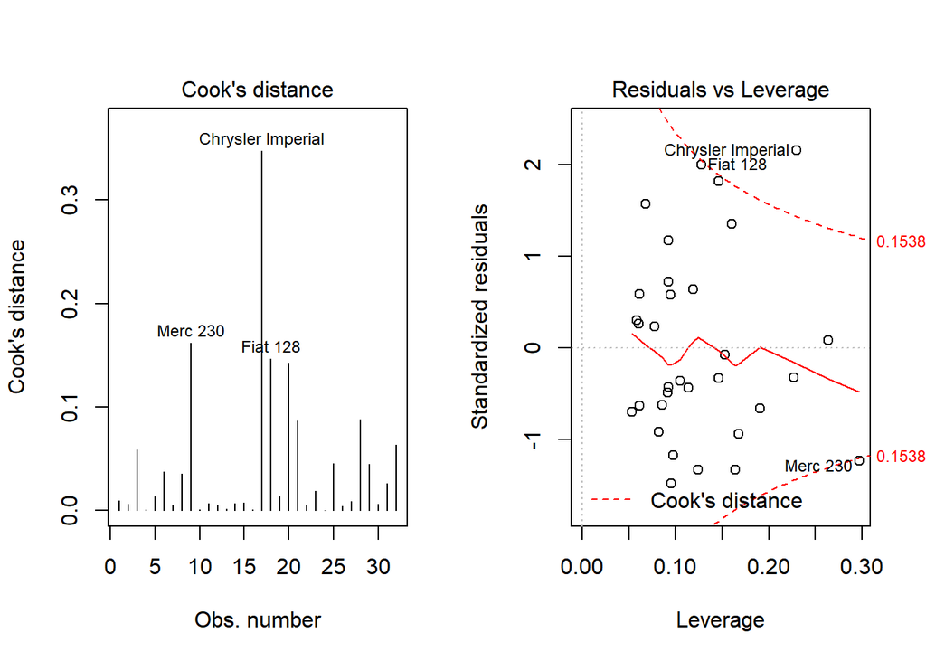

```r
par(mfrow=c(1,2))
cutoff <- 4/((nrow(mtcars)-length(model1$coefficients)-2))
plot(model1, which=c(4,5), cook.levels=cutoff)
```

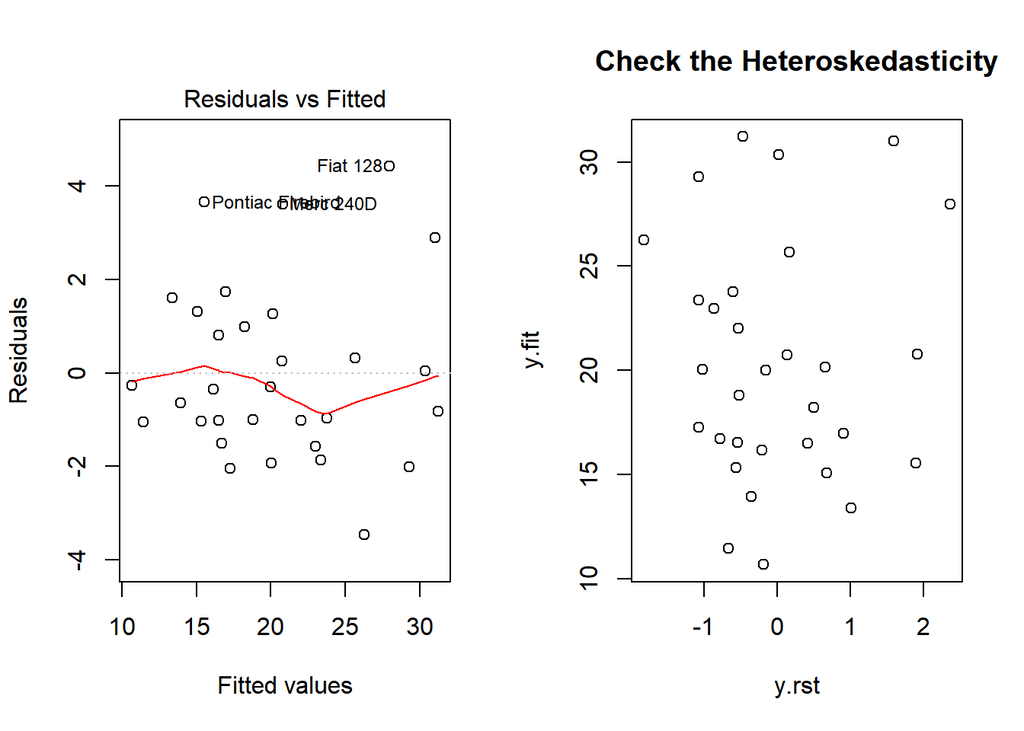

```r
plot(model_int,which = 1)
y.rst<-rstandard(model_int)
y.fit<-predict(model_int)
plot(y.fit~y.rst,main="Check the Heteroskedasticity")
```

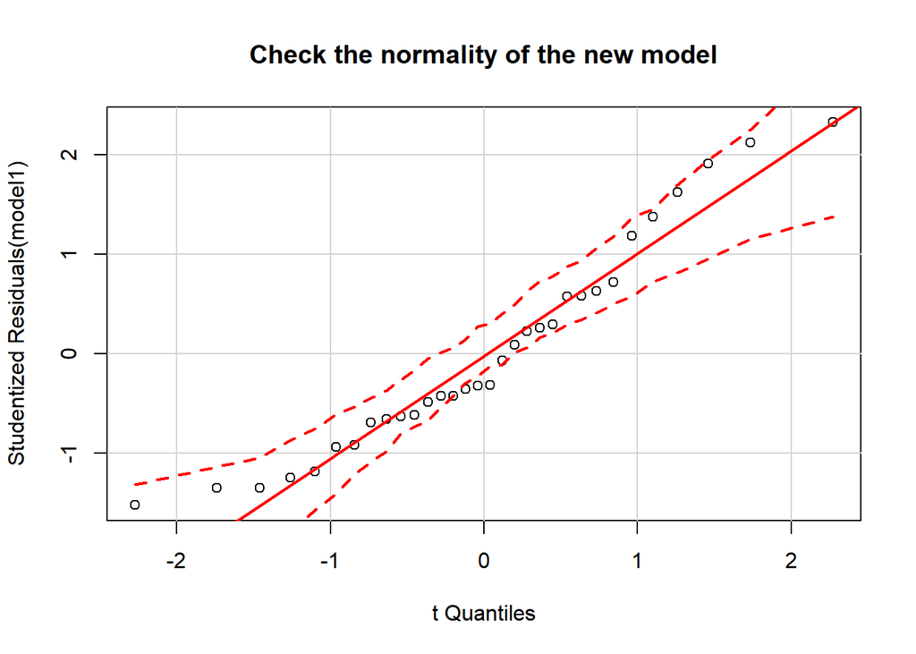

```r
par(mfrow=c(1,1))
qqPlot(model1, main = "Check the normality of the new model")
```